# INDICADORES MACROECONÓMICOS DEL ESTADO DE JALISCO

## QUÉ SON

Los indicadores macroeconómicos son estadísticas económicas que se liberan periódicamente por agencias gubernamentales y organizaciones privadas. Estos indicadores proporcionan información sobre el rendimiento económico de un país o de una región en particular y, por lo tanto, tienen un impacto significativo sobre el mercado de divisas y las operaciones comerciales.

Tomamos los datos de los índicadores que nos parecieron más importantes para ver como se encuentra Jalisco y cúal va a ser su pronóstico

## INPC (Indicador Nacional de Precios al Consumidor)

Vamos a analizar el INPC (Indice Nacional de Precios al Consumidor). Primero hay que definir que es el índice de precios al consumidor o índice de precios de consumo(comúnmente llamado por su sigla IPC) ; es un índice económico en el que se valoran los precios de un determinado conjunto de bienes y servicios.

Los datos con los que vamos a estar trabajando son mensuales desde el 2018 hasta la actualidad del estado de Jalisco y se le va a dar el tratamiento de Indice, es decir no son miles de pesos , es un conjunto de datos que se proyecta en un dato estadistico.

## INPC POR OBJETO DE GASTO

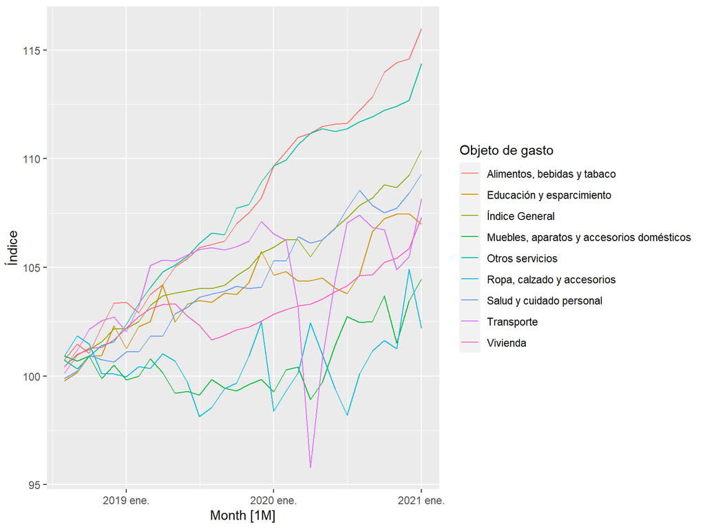

## INPC

En esta tabla podemos ver cuales son los valores maximos , minimos , promedios y las desviaciones de los diferentes objetos de gasto producidos por el indice del INPC, para hacernos una idea de cuanto son los cambios

|  | Objeto de gasto | mean | min | max | sd |
| --- | --- | --- | --- | --- | --- |
| 1 | Alimentos, bebidas y tabaco | 107.8468 | 100.745 | 115.993 | 4.53468432083813 |
| 2 | Educación y esparcimiento | 103.857133333333 | 99.793 | 107.467 | 2.07898739830208 |
| 3 | Índice General | 105.027366666667 | 100.435 | 110.398 | 2.64806061087177 |
| 4 | Muebles, aparatos y accesorios domésticos | 100.676166666667 | 98.918 | 104.476 | 1.4876643365225 |
| 5 | Otros servicios | 107.488933333333 | 100.326 | 114.386 | 4.26669216084337 |
| 6 | Ropa, calzado y accesorios | 100.5336 | 98.125 | 104.911 | 1.45125941976212 |
| 7 | Salud y cuidado personal | 104.377533333333 | 99.887 | 109.301 | 2.85375924767282 |
| 8 | Transporte | 104.5318 | 95.796 | 108.153 | 2.66751655652038 |
| 9 | Vivienda | 103.092133333333 | 100.151 | 107.296 | 1.56670910825369 |

## INPC ÍNDICE GENERAL

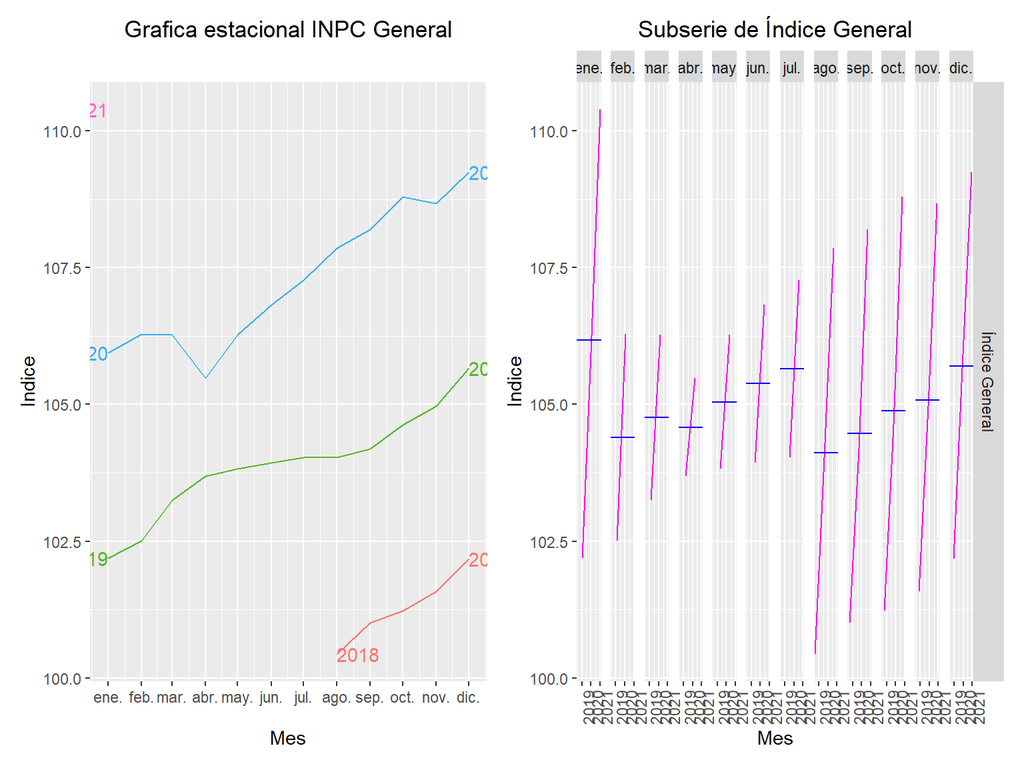

## INPC ÍNDICE GENERAL

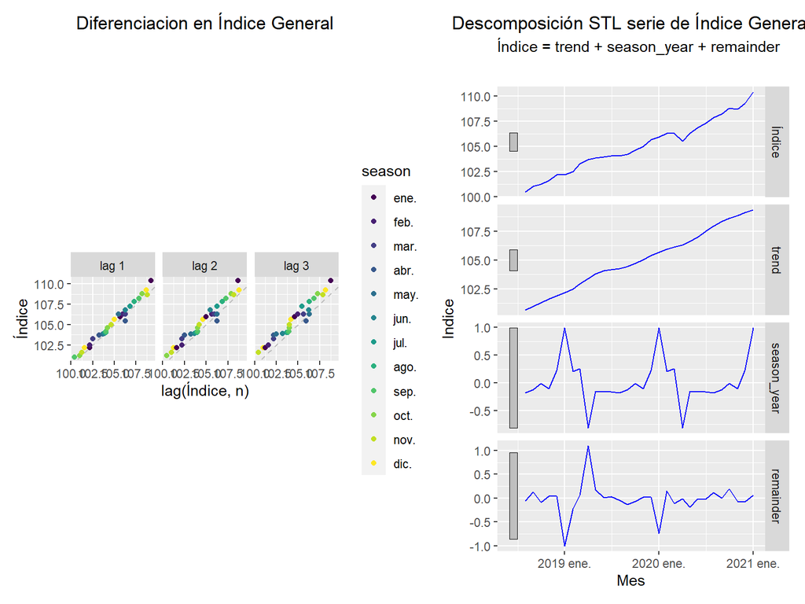

## INPC ÍNDICE GENERAL

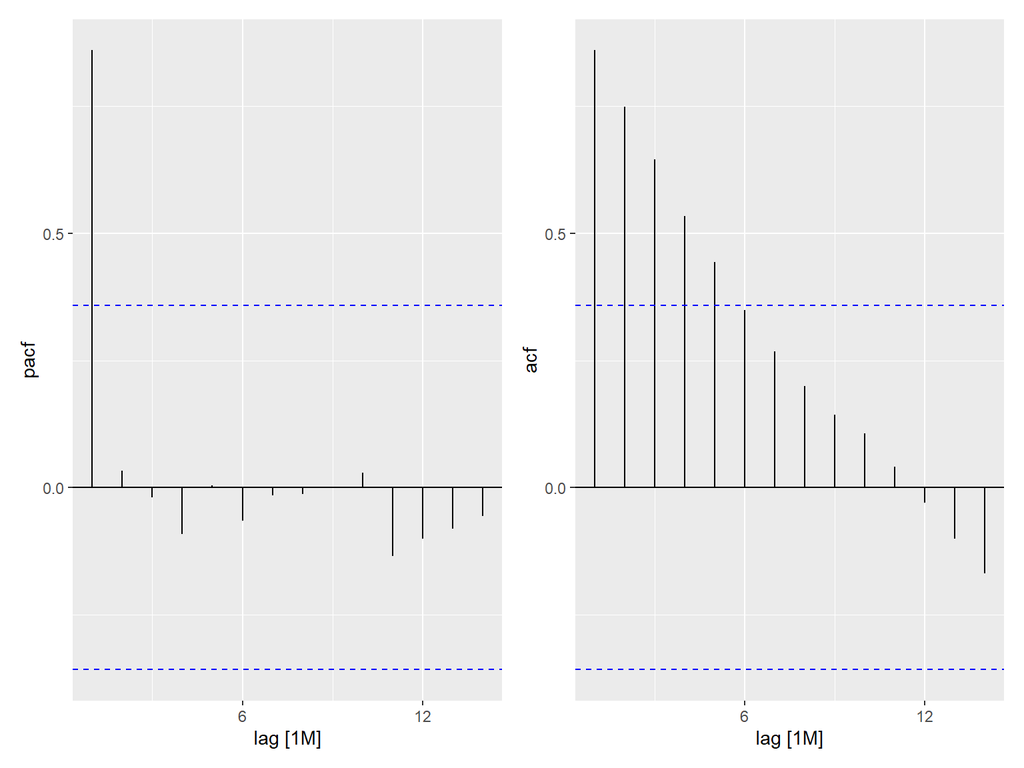

## INPC ÍNDICE GENERAL MODELO

```
## Series: Índice
## Model: ARIMA(0,1,0) w/ drift
##
## Coefficients:
##       constant
##         0.3436
## s.e.    0.0651
##
## sigma^2 estimated as 0.1275:  log likelihood=-10.73
## AIC=25.47   AICc=25.93   BIC=28.2
```

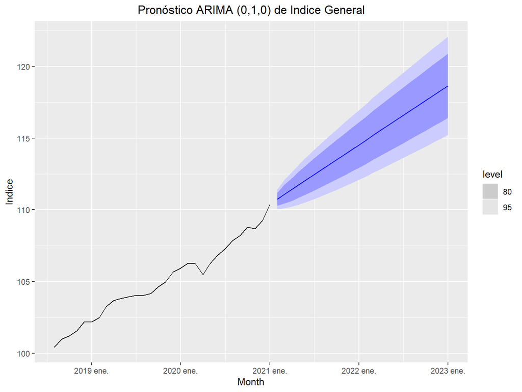

## INPC ÍNDICE GENERAL RESIDUALES

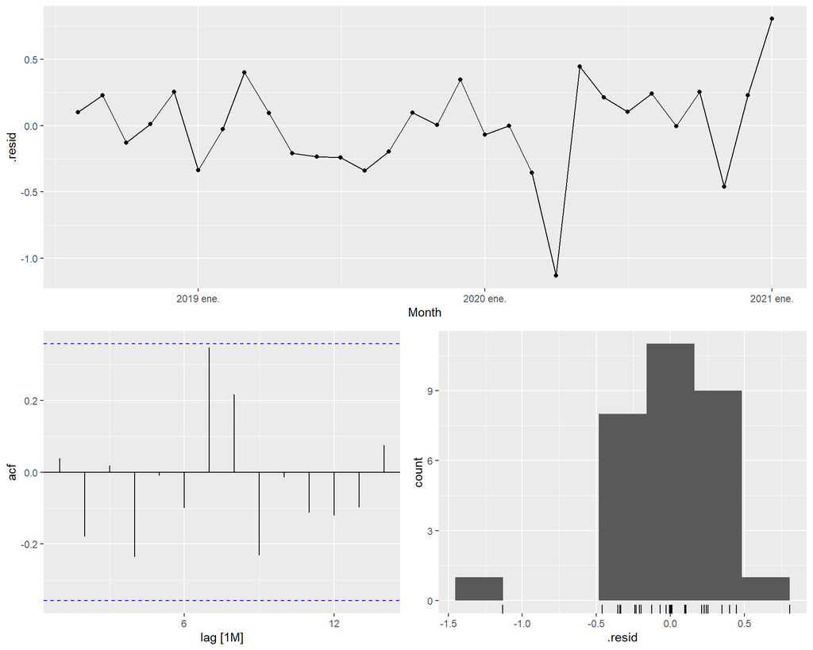

## INPC PRONÓSTICO ARIMA

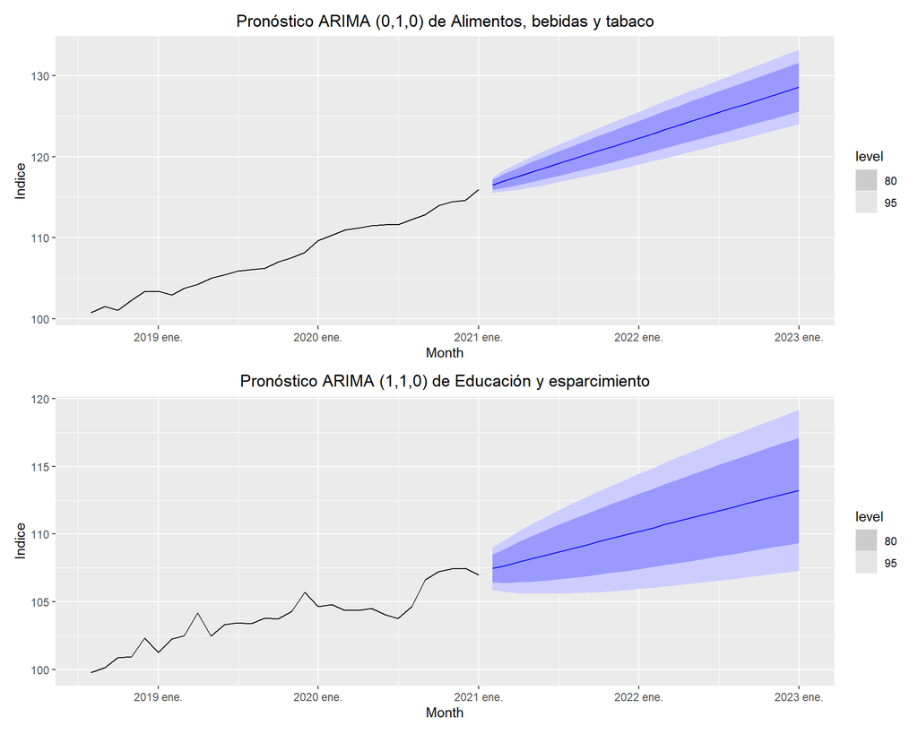

## INPC PRONÓSTICO ARIMA

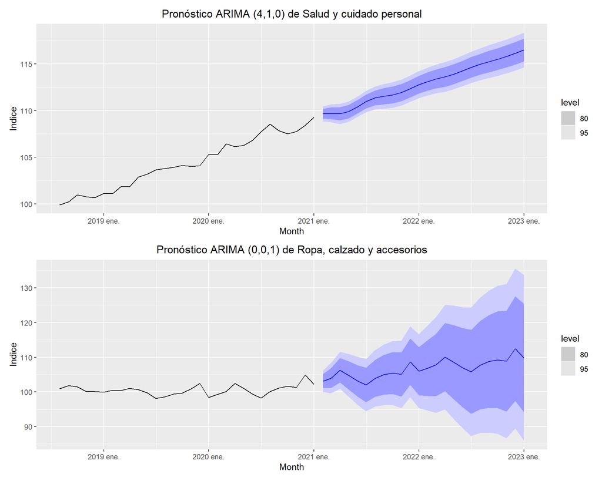

## INPC PRONÓSTICO ARIMA

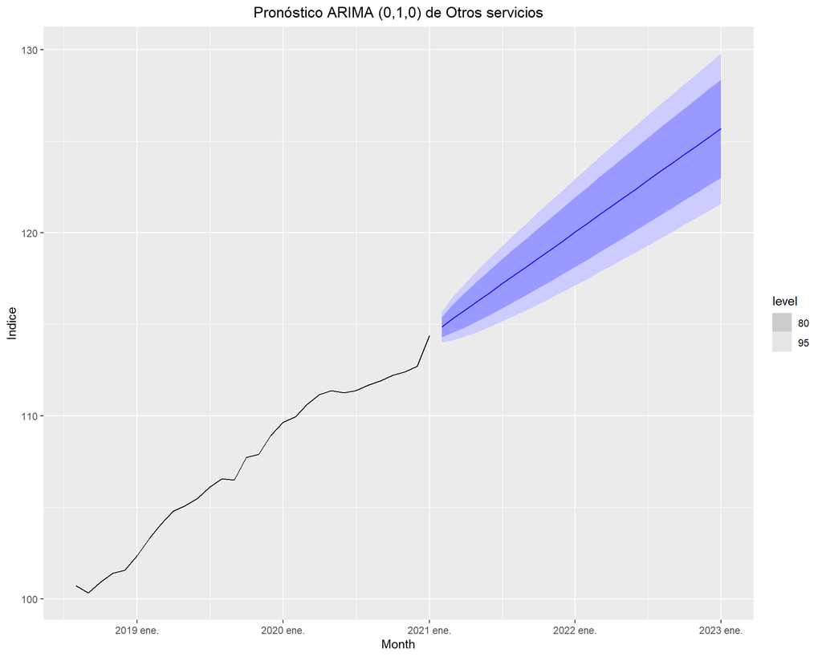

## INPC PRONÓSTICO NAIVE

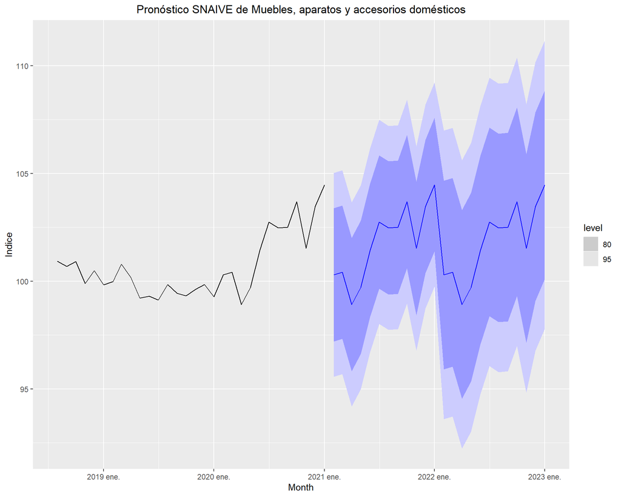

## PRONOSTICO INPC NACIONAL

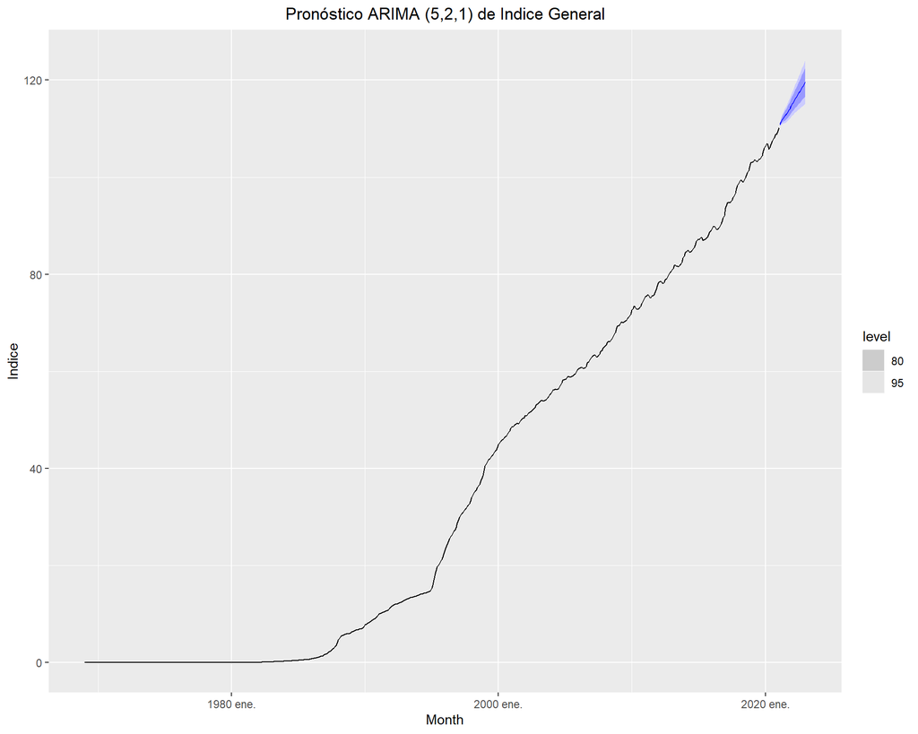

## PRONOSTICO INPC GUADALAJARA

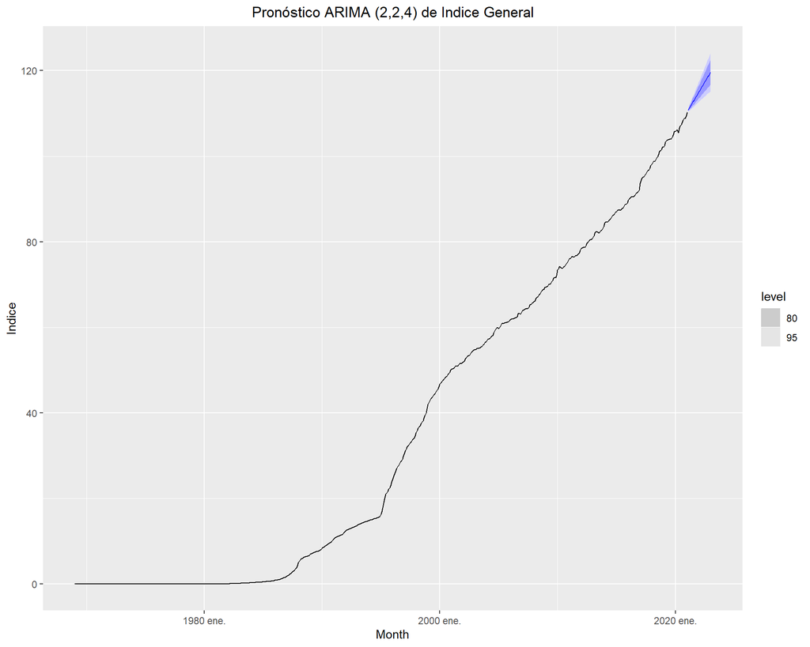

## EXPORTACIONES

Los datos que vamos a estar analizando estan en Millones de pesos y las muestras de esos datos se presentan de manera trimestral, una vez cada cuarto del año, asi vemos 4 divisiones en el total anual.

## EXPORTACIONES PRONOSTICO ARIMA

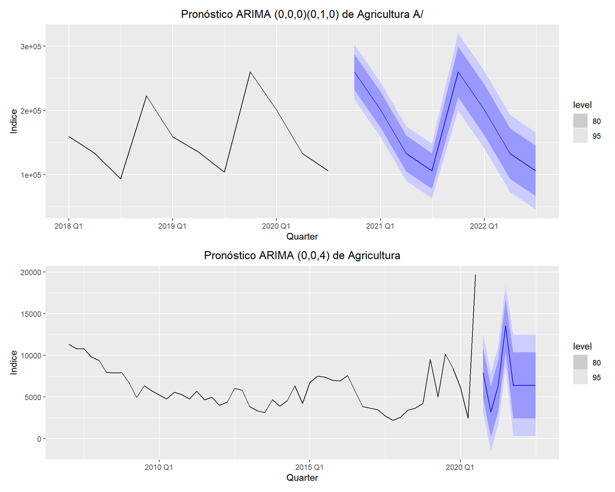

## EXPORTACIONES PRONOSTICO ARIMA

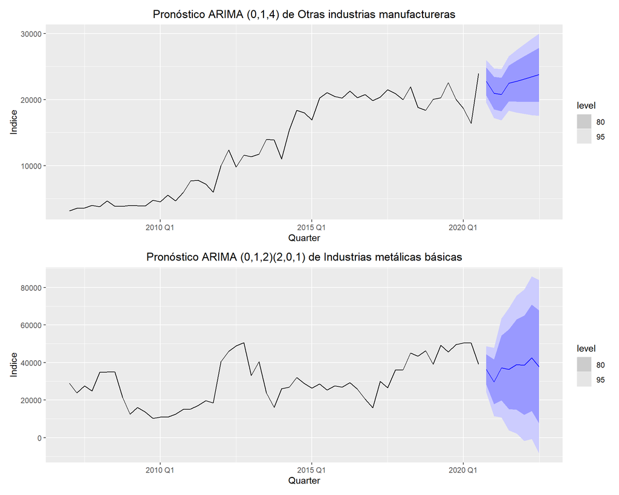

## EXPORTACIONES PRONOSTICO NAIVE

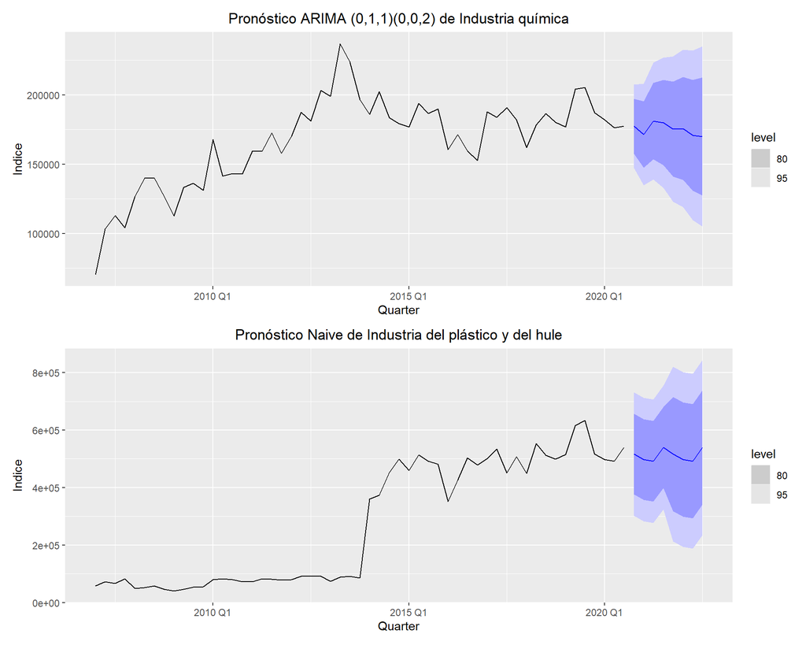

## EXPORTACIONES PRONOSTICO NAIVE

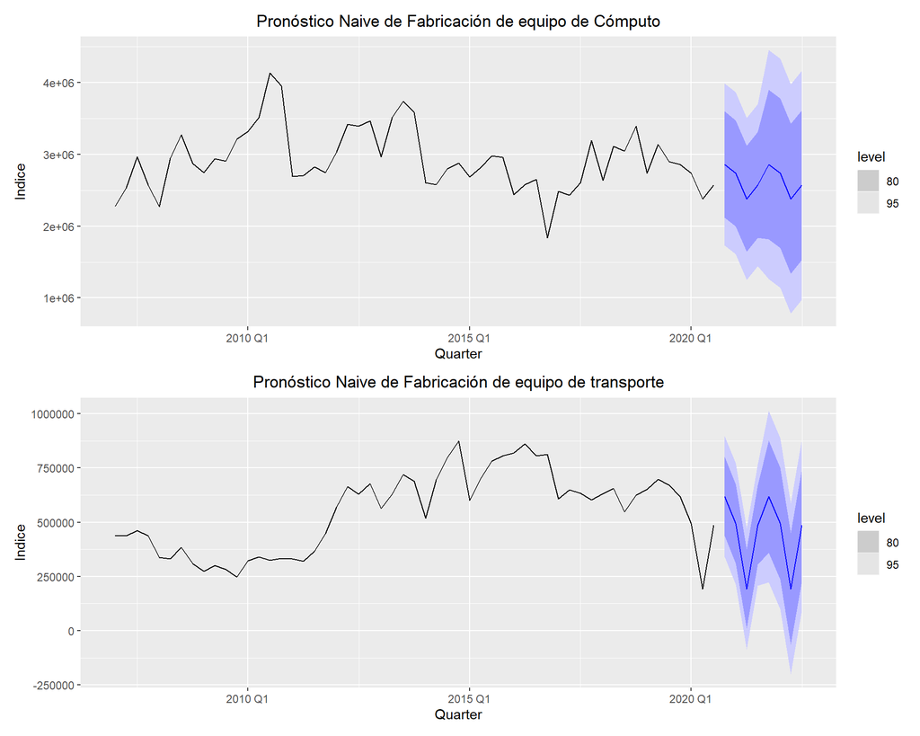